# EE4708: Assignment 6 - Support Vector Machines

## ME18B114 Prajwal Dinesh Sahu

Pulsars are a rare type of Neutron star that produces radio emissions detectable here on Earth. They are of considerable scientific interest as probes of space-time, the inter-stellar medium, and states of matter. Machine learning tools are now being used to automatically label pulsar candidates to facilitate rapid analysis. The key task is to Predict if a star is a pulsar start or not. Each candidate is described by 8 continuous variables and a single class variable. The first four are simple statistics obtained from the integrated pulse profile (folded profile). This is an array of continuous variables that describe a longitude-resolved version of the signal that has been averaged in both time and frequency. The remaining four variables are similarly obtained from the DM-SNR curve. The dataset is contained in pulsar_data_train.csv and pulsar_data_test.csv and the variables are given below:

`Mean of the integrated profile`

`Standard deviation of the integrated profile`

`Excess kurtosis of the integrated profile`

`Skewness of the integrated profile`

`Mean of the DM-SNR curve`

`Standard deviation of the DM-SNR curve`

`Excess kurtosis of the DM-SNR curve`

`Skewness of the DM-SNR curve`

`target_class`

# 1 Importing libraries and data sets

```python
import numpy as np
import pandas as pd
import seaborn as sns
import matplotlib.pyplot as plt
import warnings
warnings.filterwarnings("ignore")
%matplotlib inline
```

```python
train = pd.read_csv('pulsar_data_train.csv')
test = pd.read_csv('pulsar_data_test.csv')
```

```python
train
```

|  | Mean of the integrated profile | Standard deviation of the integrated profile | Excess kurtosis of the integrated profile | Skewness of the integrated profile | Mean of the DM-SNR curve | Standard deviation of the DM-SNR curve | Excess kurtosis of the DM-SNR curve | Skewness of the DM-SNR curve | target_class |
| --- | --- | --- | --- | --- | --- | --- | --- | --- | --- |
| 0 | 121.156250 | 48.372971 | 0.375485 | -0.013165 | 3.168896 | 18.399367 | 7.449874 | 65.159298 | 0.0 |
| 1 | 76.968750 | 36.175557 | 0.712898 | 3.388719 | 2.399666 | 17.570997 | 9.414652 | 102.722975 | 0.0 |
| 2 | 130.585938 | 53.229534 | 0.133408 | -0.297242 | 2.743311 | 22.362553 | 8.508364 | 74.031324 | 0.0 |
| 3 | 156.398438 | 48.865942 | -0.215989 | -0.171294 | 17.471572 | NaN | 2.958066 | 7.197842 | 0.0 |
| 4 | 84.804688 | 36.117659 | 0.825013 | 3.274125 | 2.790134 | 20.618009 | 8.405008 | 76.291128 | 0.0 |
| ... | ... | ... | ... | ... | ... | ... | ... | ... | ... |
| 12523 | 124.312500 | 53.179053 | -0.012418 | -0.556021 | 7.186455 | 29.308266 | 4.531382 | 21.725143 | 0.0 |
| 12524 | 115.617188 | 46.784600 | 0.218177 | 0.226757 | 6.140468 | NaN | 5.732201 | 34.357283 | 0.0 |
| 12525 | 116.031250 | 43.213846 | 0.663456 | 0.433088 | 0.785117 | 11.628149 | 17.055215 | 312.204325 | 0.0 |
| 12526 | 135.664062 | 49.933749 | -0.089940 | -0.226726 | 3.859532 | 21.501505 | 7.398395 | 62.334018 | 0.0 |
| 12527 | 120.726562 | 50.472256 | 0.346178 | 0.184797 | 0.769231 | 11.792603 | 17.662222 | 329.548016 | 0.0 |

12528 rows × 9 columns

# 2 Target Variable

```python
train.target_class.value_counts()
```

```
0.0    11375
1.0     1153
Name: target_class, dtype: int64
```

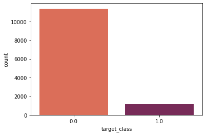

```python
sns.countplot('target_class',data= train, palette='rocket_r')
```

# 3 Pre-processing

### Missing Values

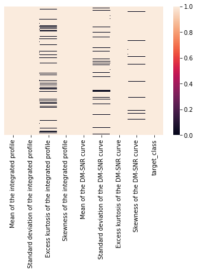

```python
sns.heatmap(train.notnull(),yticklabels=False,cmap ='rocket' )
```

```python
train =train.fillna(value=train[[' Excess kurtosis of the integrated profile',' Standard deviation of the DM-SNR curve',' Skewness of the DM-SNR curve']].median())
```

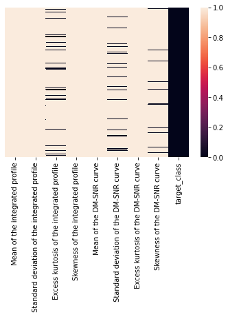

```python
sns.heatmap(test.notnull(),yticklabels=False,cmap ='rocket' )
```

```python
test =test.fillna(value=test[[' Excess kurtosis of the integrated profile',' Standard deviation of the DM-SNR curve',' Skewness of the DM-SNR curve']].median())
```

```python
test.drop('target_class',axis=1,inplace=True)
```

# 3.1 Correlation Heatmap

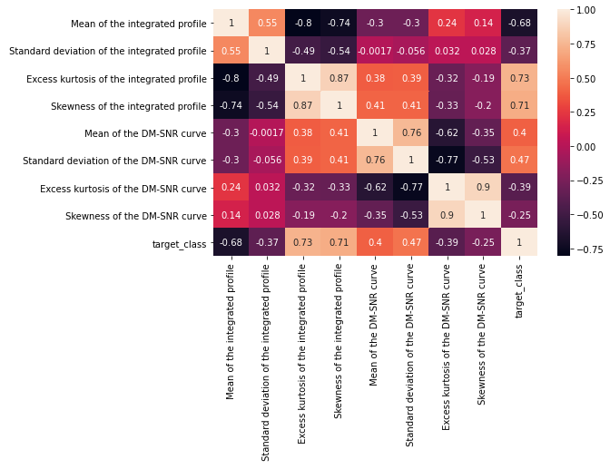

```python
P = train

plt.subplots(figsize=(8, 5))
sns.heatmap(P.corr(), annot=True, cmap="rocket")
plt.show()
```

# 3.2 Pairplot

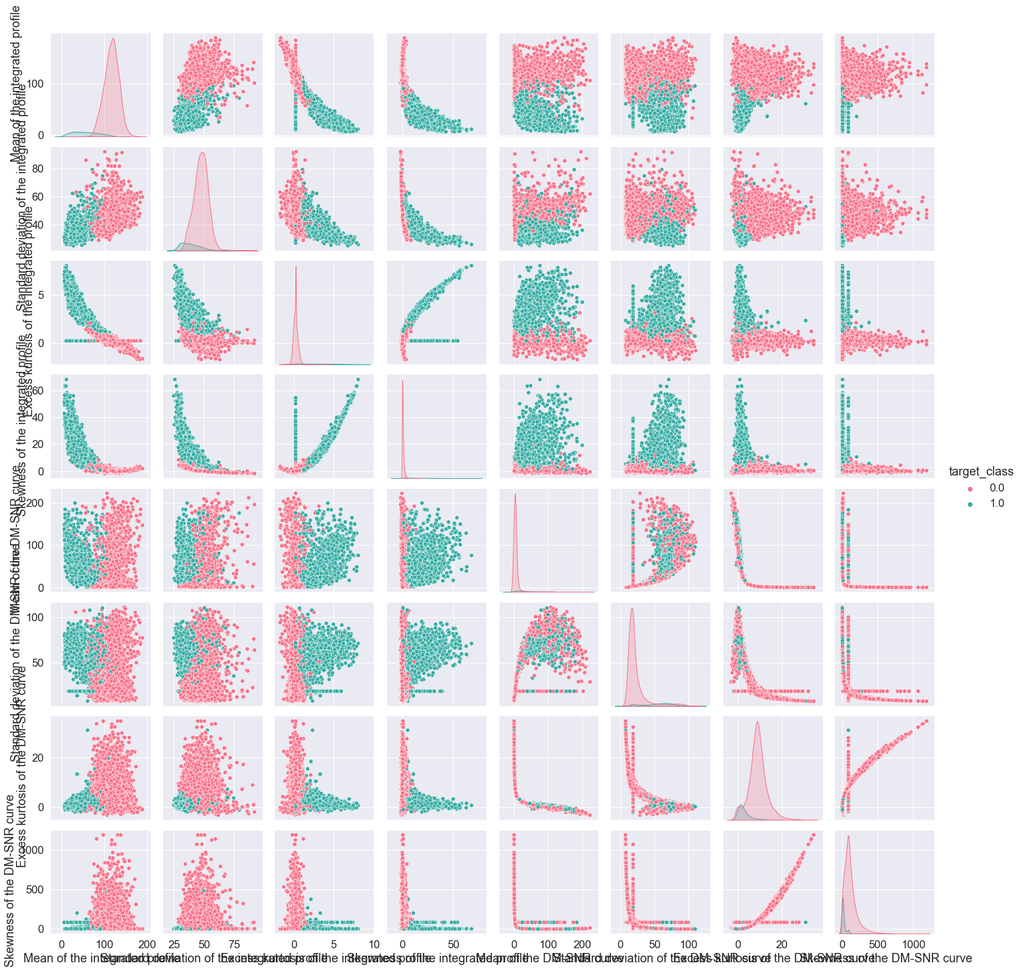

```python
sns.pairplot(train, hue='target_class', palette='husl')
```

# 4 Variables

```python
cols = train.columns
cols
```

```
Index([' Mean of the integrated profile',
       ' Standard deviation of the integrated profile',
       ' Excess kurtosis of the integrated profile',
       ' Skewness of the integrated profile', ' Mean of the DM-SNR curve',
       ' Standard deviation of the DM-SNR curve',
       ' Excess kurtosis of the DM-SNR curve', ' Skewness of the DM-SNR curve',
       'target_class'],
      dtype='object')
```

## 4.1 Mean of the integrated profile

```python
train[' Mean of the integrated profile'].describe()
```

```
count    12528.000000
mean       111.041841
std         25.672828
min          5.812500
25%        100.871094
50%        115.183594
75%        127.109375
max        189.734375
Name:  Mean of the integrated profile, dtype: float64
```

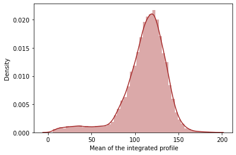

```python
sns.distplot(train[' Mean of the integrated profile'], color='Brown')
```

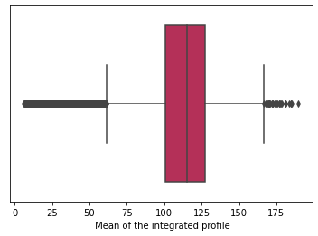

```python
sns.boxplot(train[' Mean of the integrated profile'], palette ='rocket_r')
```

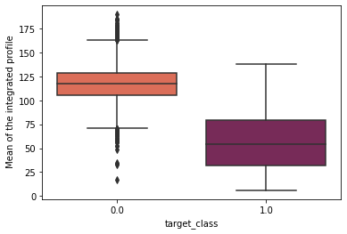

```python
sns.boxplot(x = 'target_class', y = train[' Mean of the integrated profile'], data =train, palette ='rocket_r')
```

## 4.2 Standard deviation of the integrated profile

```python
train[' Standard deviation of the integrated profile'].describe()
```

```
count    12528.000000
mean        46.521437
std          6.801077
min         24.772042
25%         42.362222
50%         46.931022
75%         50.979103
max         91.808628
Name:  Standard deviation of the integrated profile, dtype: float64
```

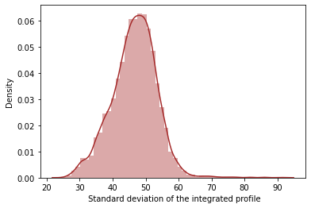

```python
sns.distplot(train[' Standard deviation of the integrated profile'], color='Brown')
```

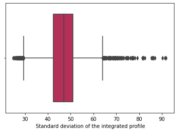

```python
sns.boxplot(train[' Standard deviation of the integrated profile'], palette ='rocket_r')
```

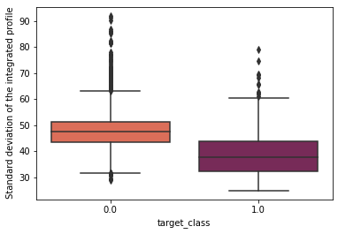

```python
sns.boxplot(x = 'target_class', y = train[' Standard deviation of the integrated profile'], data =train, palette ='rocket_r')
```

## 4.3 Excess kurtosis of the integrated profile

```python
train[' Excess kurtosis of the integrated profile'].describe()
```

```
count    12528.000000
mean         0.443251
std          0.992144
min         -1.738021
25%          0.057820
50%          0.223678
75%          0.421239
max          8.069522
Name:  Excess kurtosis of the integrated profile, dtype: float64
```

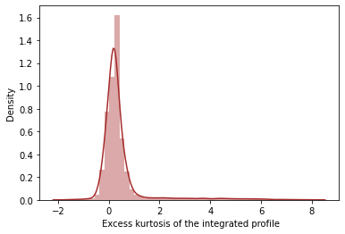

```python
sns.distplot(train[' Excess kurtosis of the integrated profile'], color='Brown')
```

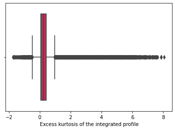

```python
sns.boxplot(train[' Excess kurtosis of the integrated profile'], palette ='rocket_r')
```

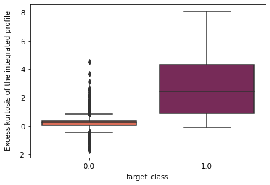

```python
sns.boxplot(x = 'target_class', y = train[' Excess kurtosis of the integrated profile'], data =train, palette ='rocket_r')
```

## 4.4 Skewness of the integrated profile

```python
train[' Skewness of the integrated profile'].describe()
```

```
count    12528.000000
mean         1.778431
std          6.208450
min         -1.791886
25%         -0.188142
50%          0.203317
75%          0.932374
max         68.101622
Name:  Skewness of the integrated profile, dtype: float64
```

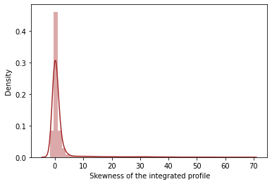

```python
sns.distplot(train[' Skewness of the integrated profile'], color='Brown')
```

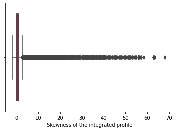

```python
sns.boxplot(train[' Skewness of the integrated profile'], palette ='rocket_r')
```

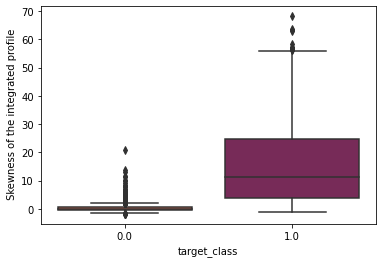

```python
sns.boxplot(x = 'target_class', y = train[' Skewness of the integrated profile'], data =train, palette ='rocket_r')
```

## 4.5 Mean of the DM-SNR curve

```python
train[' Mean of the DM-SNR curve'].describe()
```

```
count    12528.000000
mean        12.674758
std         29.613230
min          0.213211
25%          1.910535
50%          2.792642
75%          5.413253
max        222.421405
Name:  Mean of the DM-SNR curve, dtype: float64
```

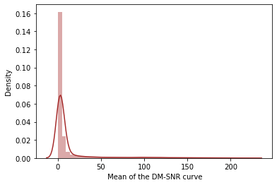

```python
sns.distplot(train[' Mean of the DM-SNR curve'], color='Brown')
```

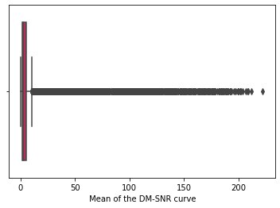

```python
sns.boxplot(train[' Mean of the DM-SNR curve'], palette ='rocket_r')
```

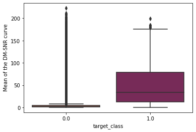

```python
sns.boxplot(x = 'target_class', y = train[' Mean of the DM-SNR curve'], data =train, palette ='rocket_r')
```

## 4.6 Skewness of the integrated profile

```python
train[' Skewness of the integrated profile'].describe()
```

```
count    12528.000000
mean         1.778431
std          6.208450
min         -1.791886
25%         -0.188142
50%          0.203317
75%          0.932374
max         68.101622
Name:  Skewness of the integrated profile, dtype: float64
```

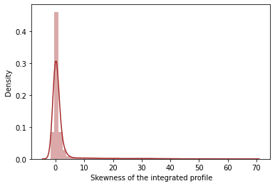

```python
sns.distplot(train[' Skewness of the integrated profile'], color='Brown')
```

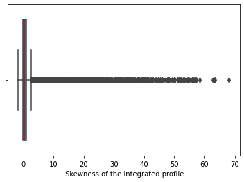

```python
sns.boxplot(train[' Skewness of the integrated profile'], palette ='rocket_r')
```

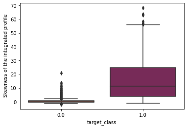

```python
sns.boxplot(x = 'target_class', y = train[' Skewness of the integrated profile'], data =train, palette ='rocket_r')
```

## 4.7 Excess kurtosis of the DM-SNR curve

```python
train[' Excess kurtosis of the DM-SNR curve'].describe()
```

```
count    12528.000000
mean         8.333489
std          4.535783
min         -3.139270
25%          5.803063
50%          8.451097
75%         10.727927
max         34.539844
Name:  Excess kurtosis of the DM-SNR curve, dtype: float64
```

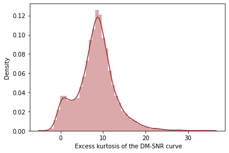

```python
sns.distplot(train[' Excess kurtosis of the DM-SNR curve'], color='Brown')
```

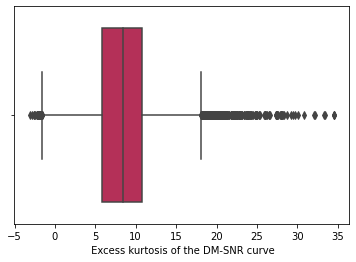

```python
sns.boxplot(train[' Excess kurtosis of the DM-SNR curve'], palette ='rocket_r')
```

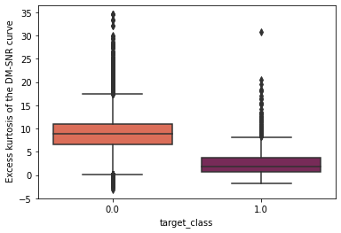

```python
sns.boxplot(x = 'target_class', y = train[' Excess kurtosis of the DM-SNR curve'], data =train, palette ='rocket_r')
```

## 4.8 Skewness of the DM-SNR curve

```python
train[' Skewness of the DM-SNR curve'].describe()
```

```
count    12528.000000
mean       104.408308
std        104.799639
min         -1.976976
25%         38.128424
50%         83.126301
75%        135.774973
max       1191.000837
Name:  Skewness of the DM-SNR curve, dtype: float64
```

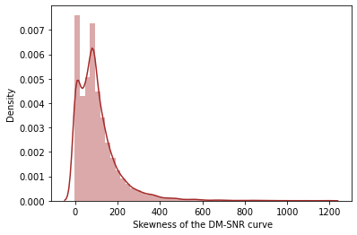

```python
sns.distplot(train[' Skewness of the DM-SNR curve'], color='Brown')
```

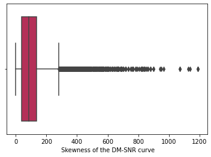

```python
sns.boxplot(train[' Skewness of the DM-SNR curve'], palette ='rocket_r')
```

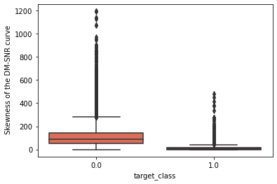

```python
sns.boxplot(x = 'target_class', y = train[' Skewness of the DM-SNR curve'], data =train, palette ='rocket_r')
```

# 5 Building Model

## 5.1 Train-Test Split

```python
from sklearn.model_selection import train_test_split
```

```python
X_train, X_test, y_train, y_test = train_test_split(train.drop(['target_class'],axis=1), train['target_class'], test_size=.30, random_state=1)
```

## 5.2 Scaling

```python
from sklearn.preprocessing import StandardScaler, RobustScaler, MinMaxScaler
```

```python
scaler = RobustScaler()
```

```python
cols = X_train.columns
cols
```

```
Index([' Mean of the integrated profile',
       ' Standard deviation of the integrated profile',
       ' Excess kurtosis of the integrated profile',
       ' Skewness of the integrated profile', ' Mean of the DM-SNR curve',
       ' Standard deviation of the DM-SNR curve',
       ' Excess kurtosis of the DM-SNR curve',
       ' Skewness of the DM-SNR curve'],
      dtype='object')
```

```python
X_train = pd.DataFrame(data = X_train)
X_train[cols] = scaler.fit_transform(X_train[cols])
```

```python
X_test = pd.DataFrame(data = X_test)
X_test[cols] = scaler.fit_transform(X_test[cols])
```

```python
test = pd.DataFrame(data = test)
test[cols] = scaler.fit_transform(test[cols])
```

```python
test
```

|  | Mean of the integrated profile | Standard deviation of the integrated profile | Excess kurtosis of the integrated profile | Skewness of the integrated profile | Mean of the DM-SNR curve | Standard deviation of the DM-SNR curve | Excess kurtosis of the DM-SNR curve | Skewness of the DM-SNR curve |
| --- | --- | --- | --- | --- | --- | --- | --- | --- |
| 0 | 0.082688 | 0.216528 | -0.115409 | -0.285360 | 0.056949 | -0.068919 | -0.052937 | -0.026536 |
| 1 | -1.507630 | -1.449219 | 5.028738 | 7.638683 | 0.257133 | 0.283913 | -0.270795 | -0.262546 |
| 2 | -0.442006 | -0.003974 | 0.774595 | 0.572574 | -0.161183 | -0.248266 | 0.191979 | 0.244328 |
| 3 | -0.526498 | 0.178350 | 2.192822 | 0.871015 | 21.756213 | 5.336178 | -1.601562 | -0.849076 |
| 4 | -0.058934 | 0.180794 | 0.179605 | 0.095323 | 0.952485 | 0.681532 | -0.779341 | -0.614181 |
| ... | ... | ... | ... | ... | ... | ... | ... | ... |
| 5365 | 0.068255 | 0.470919 | -0.639111 | -0.334418 | 0.462379 | 0.682759 | -0.354577 | -0.370766 |
| 5366 | 0.008419 | 0.773802 | 0.420281 | -0.308722 | -0.015992 | 0.194129 | 0.011578 | -0.041543 |
| 5367 | 0.824175 | 0.216962 | 0.000000 | -0.111191 | -0.005637 | 0.012346 | -0.108504 | -0.123519 |
| 5368 | -0.317823 | 0.233206 | 0.051535 | -0.041584 | -0.137483 | -0.265654 | 0.126596 | 0.195270 |
| 5369 | -0.156957 | -1.006102 | 0.650544 | 1.357154 | 0.441440 | 0.309760 | -0.495548 | -0.428198 |

5370 rows × 8 columns

## 5.3 Model Training

```python
from sklearn.svm import LinearSVC, SVC
```

```python
SVM = SVC(random_state=1).fit(X_train, y_train)
```

```python
SVM.score(X_train,y_train)
```

```
0.9757098871022921
```

```python
SVM.score(X_test,y_test)
```

```
0.9763234902899708
```

## 5.4 Grid Search

```python
from sklearn.model_selection import RandomizedSearchCV
```

```python
SVM_param_random = {'C': [0.01,0.1, 1, 10, 100, 1000],
              'gamma': [1, 0.1, 0.01, 0.001, 0.0001],
              'kernel': ['rbf'],
              'tol':[0.01,0.001,0.0001],
              'degree': [2,3,4,5]}

SVM_random1 = RandomizedSearchCV(SVM, param_distributions = SVM_param_random, cv = 5, n_jobs=-1)
```

```python
SVM_random1.fit(X_train, y_train)
```

```
RandomizedSearchCV(cv=5, estimator=SVC(random_state=1), n_jobs=-1,
                   param_distributions={'C': [0.01, 0.1, 1, 10, 100, 1000],
                                        'degree': [2, 3, 4, 5],
                                        'gamma': [1, 0.1, 0.01, 0.001, 0.0001],
                                        'kernel': ['rbf'],
                                        'tol': [0.01, 0.001, 0.0001]})
```

```python
SVM_random1.best_estimator_
```

```
SVC(C=100, degree=5, gamma=0.01, random_state=1, tol=0.01)
```

```python
SVM_best = SVC(C=1000, gamma=0.001, random_state=1, tol=0.0001).fit(X_train, y_train)
```

```python
SVM_best.score(X_train,y_train)
```

```
0.9789029535864979
```

```python
SVM_best.score(X_test,y_test)
```

```
0.9800478850758181
```

## 6.1 Metrics

```python
from sklearn.metrics import accuracy_score,f1_score
from sklearn.metrics import classification_report
from sklearn.metrics import confusion_matrix
```

```python
pred_test = SVM_best.predict(X_test)
pred_train = SVM_best.predict(X_train)
```

```python
cm = confusion_matrix(y_test, pred_test)
cm
```

```
array([[3397,   18],
       [  57,  287]], dtype=int64)
```

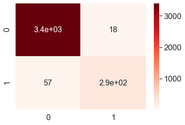

```python
df_cm = pd.DataFrame(cm)

sns.set(font_scale=1.5)
sns.heatmap(df_cm, annot=True, annot_kws={"size": 16},cmap="Reds") # font size

plt.show()
```

```python
print(classification_report(y_test, pred_test))
```

```
              precision    recall  f1-score   support

         0.0       0.98      0.99      0.99      3415
         1.0       0.94      0.83      0.88       344

    accuracy                           0.98      3759
   macro avg       0.96      0.91      0.94      3759
weighted avg       0.98      0.98      0.98      3759
```

## 6.2 Predictions

```python
pred = SVM_best.predict(test)
```

```python
predicted_data=pd.DataFrame(pred,columns=['Pulsar'])
```

```python
predicted_data
```

|  | Pulsar |
| --- | --- |
| 0 | 0.0 |
| 1 | 1.0 |
| 2 | 0.0 |
| 3 | 0.0 |
| 4 | 0.0 |
| ... | ... |
| 5365 | 0.0 |
| 5366 | 0.0 |
| 5367 | 0.0 |
| 5368 | 0.0 |
| 5369 | 0.0 |

5370 rows × 1 columns

```python
me18b114_assign6_pred = pd.concat([test,predicted_data],axis=1)
me18b114_assign6_pred
```

|  | Mean of the integrated profile | Standard deviation of the integrated profile | Excess kurtosis of the integrated profile | Skewness of the integrated profile | Mean of the DM-SNR curve | Standard deviation of the DM-SNR curve | Excess kurtosis of the DM-SNR curve | Skewness of the DM-SNR curve | Pulsar |
| --- | --- | --- | --- | --- | --- | --- | --- | --- | --- |
| 0 | 0.082688 | 0.216528 | -0.115409 | -0.285360 | 0.056949 | -0.068919 | -0.052937 | -0.026536 | 0.0 |
| 1 | -1.507630 | -1.449219 | 5.028738 | 7.638683 | 0.257133 | 0.283913 | -0.270795 | -0.262546 | 1.0 |
| 2 | -0.442006 | -0.003974 | 0.774595 | 0.572574 | -0.161183 | -0.248266 | 0.191979 | 0.244328 | 0.0 |
| 3 | -0.526498 | 0.178350 | 2.192822 | 0.871015 | 21.756213 | 5.336178 | -1.601562 | -0.849076 | 0.0 |
| 4 | -0.058934 | 0.180794 | 0.179605 | 0.095323 | 0.952485 | 0.681532 | -0.779341 | -0.614181 | 0.0 |
| ... | ... | ... | ... | ... | ... | ... | ... | ... | ... |
| 5365 | 0.068255 | 0.470919 | -0.639111 | -0.334418 | 0.462379 | 0.682759 | -0.354577 | -0.370766 | 0.0 |
| 5366 | 0.008419 | 0.773802 | 0.420281 | -0.308722 | -0.015992 | 0.194129 | 0.011578 | -0.041543 | 0.0 |
| 5367 | 0.824175 | 0.216962 | 0.000000 | -0.111191 | -0.005637 | 0.012346 | -0.108504 | -0.123519 | 0.0 |
| 5368 | -0.317823 | 0.233206 | 0.051535 | -0.041584 | -0.137483 | -0.265654 | 0.126596 | 0.195270 | 0.0 |
| 5369 | -0.156957 | -1.006102 | 0.650544 | 1.357154 | 0.441440 | 0.309760 | -0.495548 | -0.428198 | 0.0 |

5370 rows × 9 columns

```python
me18b114_assign6_pred.to_csv('me18b114_assign6_predictions.csv')
```

## ------------- THE END -----------------